# Lab 4: Data Visualization

Author

Nate Truettner

## 1. Read in the data

```r
if (!file.exists("covid_processed.csv"))
  download.file(
    url = "https://raw.githubusercontent.com/dmcable/BIOSTAT620W26/main/data/covid/covid_processed.csv",
    destfile = "covid_processed.csv",
    method   = "libcurl",
    timeout  = 60
    )

covid <- read.csv('covid_processed.csv')
```

## 2. Prepare the data

```r
covid <- mutate(covid,
                case_rate = cases/pop*100000,
                death_rate = deaths/pop*100000,
                hosp_rate = hosp/pop*100000,
                series_prop = series/pop,
                booster_prop = booster/pop)
covid <- mutate(covid,
                date = ymd(date))
state_avg <- covid %>%
  group_by(state) %>%
  summarise(
    mean_case_rate = mean(case_rate, na.rm=TRUE),
    mean_death_rate = mean(death_rate, na.rm=TRUE),
    mean_hosp_rate = mean(hosp_rate, na.rm=TRUE),
    mean_series_prop = mean(series_prop, na.rm=TRUE),
    mean_booster_prop = mean(booster_prop, na.rm=TRUE),
    population = first(pop),
    region = first(region),
    region_name = first(region_name)
  )

median_pop <- median(state_avg$population)
state_avg <- mutate(state_avg,
                    pop_indicator = ifelse(population > median_pop, 1, 0))
state_avg$region = as.factor(state_avg$region)
```

## 3. Geom_violin

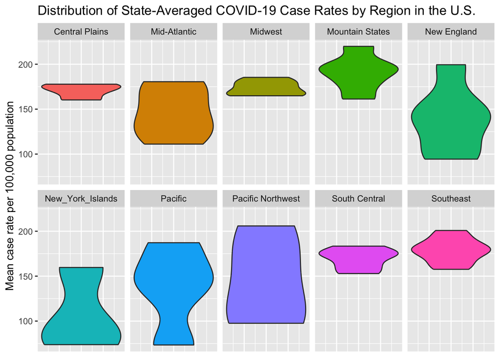

```r
ggplot(state_avg) +
  geom_violin(aes(x = 1, y = mean_case_rate, fill = region_name)) +
  facet_wrap(~ region_name, nrow = 2) +
  labs(
    title = "Distribution of State-Averaged COVID-19 Case Rates by Region in the U.S.",
    y = "Mean case rate per 100,000 population",
    x = NULL
  ) +
  theme(
    axis.text.x = element_blank(),
    axis.ticks.x = element_blank(),
    legend.position = "none"
  )
```

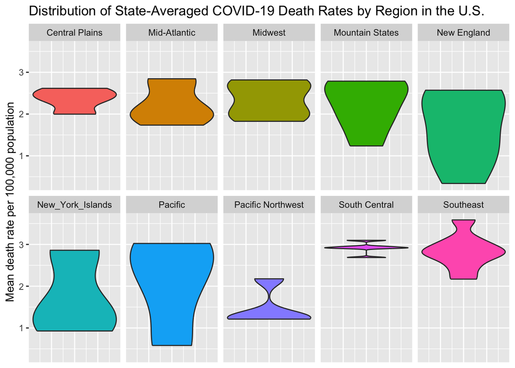

```r
ggplot(state_avg) +
  geom_violin(aes(x = 1, y = mean_death_rate, fill = region_name)) +
  facet_wrap(~ region_name, nrow = 2) +
  labs(
    title = "Distribution of State-Averaged COVID-19 Death Rates by Region in the U.S.",
    y = "Mean death rate per 100,000 population",
    x = NULL
  ) +
  theme(
    axis.text.x = element_blank(),
    axis.ticks.x = element_blank(),
    legend.position = "none"
  )
```

Examining these violin plots, we notice some potentially interesting trends. Some regions have a very narrow range of mean case rate while some have a more broad range; I wonder if this could be due to political homogeneity in the narrow regions and heterogeneity in the broad regions. If states are closely aligned in COVID policy, it’s not a stretch to think that their case rates could be similar to one another. Generally, the death rate distributions are more broad than the case rate distributions, which could reflect differences in average age across states and regions.

## 4. Geom_point and stat_smooth

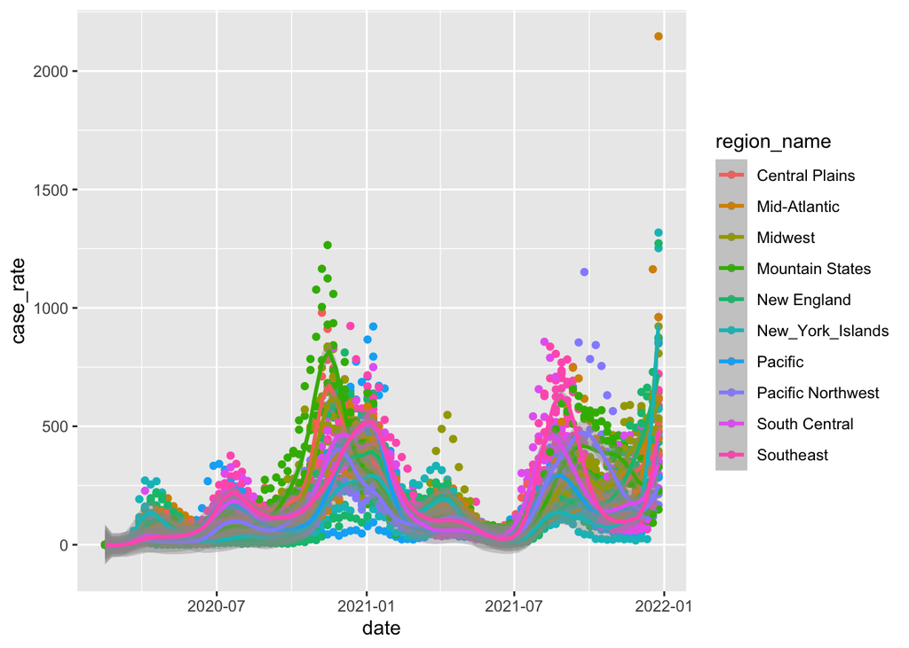

```r
first_date <- first(covid$date)
two_weeks <- first_date + 14
two_week_df <- covid %>%
  filter(date > two_weeks)
ggplot(two_week_df) +
  geom_point(aes(x=date, y=case_rate, color=region_name)) +
  stat_smooth(aes(x=date, y=case_rate, color=region_name), span = 0.1)
```

The lm method does not work well as case rates fluctuate greatly over time, so we will keep the default setting of stat_smooth. If the span parameter is set too high, we will fail to capture the peaks and valleys of the case rates, but if it is too low we will have too much noise in the data. I found that setting span to 0.1 yields a decent balance between the two. From this plot, we notice that the pink lines (southern regions) are pretty consistently higher than the blue lines (Pacific + New York islands). Generally, the regions experience peaks and valleys in case rates at roughly the same time.

## 5. Geom_bar

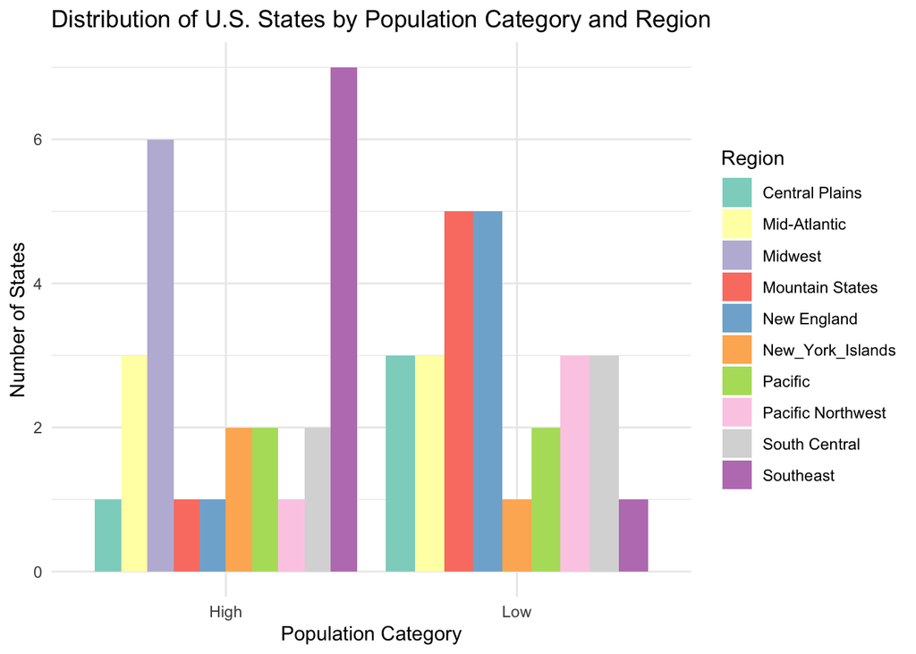

```r
state_avg <- state_avg %>%
  mutate(
    pop_indicator = ifelse(pop_indicator == 1, "High", "Low")
  )
ggplot(state_avg, aes(x = pop_indicator, fill = region_name)) +
  geom_bar(position = "dodge") +
  scale_fill_brewer(palette = "Set3") +
  labs(
    title = "Distribution of U.S. States by Population Category and Region",
    x = "Population Category",
    y = "Number of States",
    fill = "Region"
  ) +
  theme_minimal()
```

Looking at the chart, it appears that the southeast and midwest regions have a lot of states in the high population category and few in the low category. The mountain states and New England appear to be the opposite case, with more low population states than high.

## 6. Stat_summary

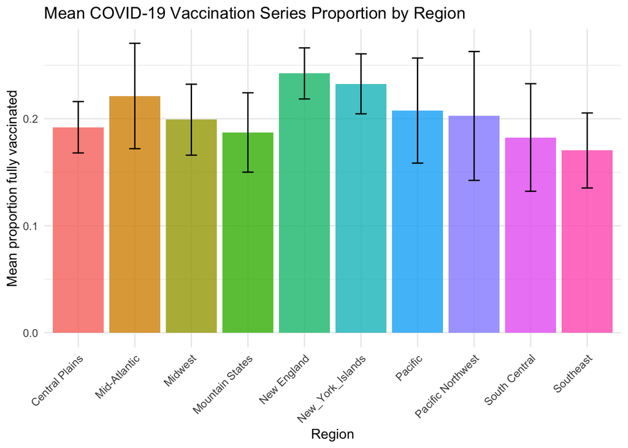

```r
#Vaccination
ggplot(state_avg, aes(x = region_name, y = mean_series_prop, fill = region_name)) +
  stat_summary(
    fun.data = "mean_sdl",
    geom = "bar",
    alpha = 0.8
  ) +
  stat_summary(
    fun.data = "mean_sdl",
    geom = "errorbar",
    width = 0.2
  ) +
  labs(
    title = "Mean COVID-19 Vaccination Series Proportion by Region",
    x = "Region",
    y = "Mean proportion fully vaccinated"
  ) +
  theme_minimal() +
  theme(axis.text.x = element_text(angle = 45, hjust = 1),
        legend.position = "none")
```

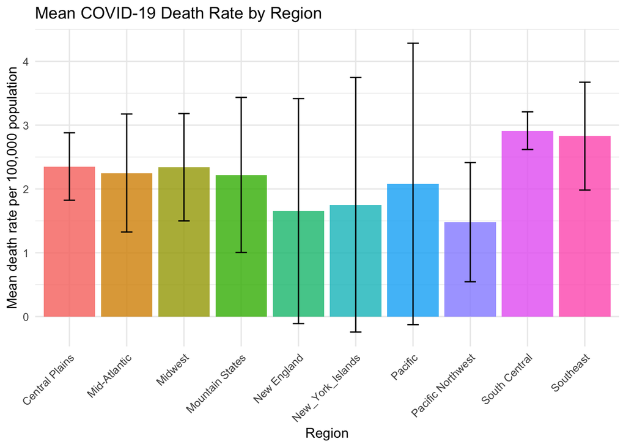

```r
#Death
ggplot(state_avg, aes(x = region_name, y = mean_death_rate, fill = region_name)) +
  stat_summary(
    fun.data = "mean_sdl",
    geom = "bar",
    alpha = 0.8
  ) +
  stat_summary(
    fun.data = "mean_sdl",
    geom = "errorbar",
    width = 0.2
  ) +
  labs(
    title = "Mean COVID-19 Death Rate by Region",
    x = "Region",
    y = "Mean death rate per 100,000 population"
  ) +
  theme_minimal() +
  theme(axis.text.x = element_text(angle = 45, hjust = 1),
        legend.position = "none")
```

The most vaccinated regions appear to be New England and the New York Islands, while the least vaccinated are the southeast and south central U.S. Comparing this to the death plot, we see generally that higher vaccination is associated with lower death rates, as NE and NY have relatively low death rates while SE and South Central have relatively high death rates.

## 7. Maps

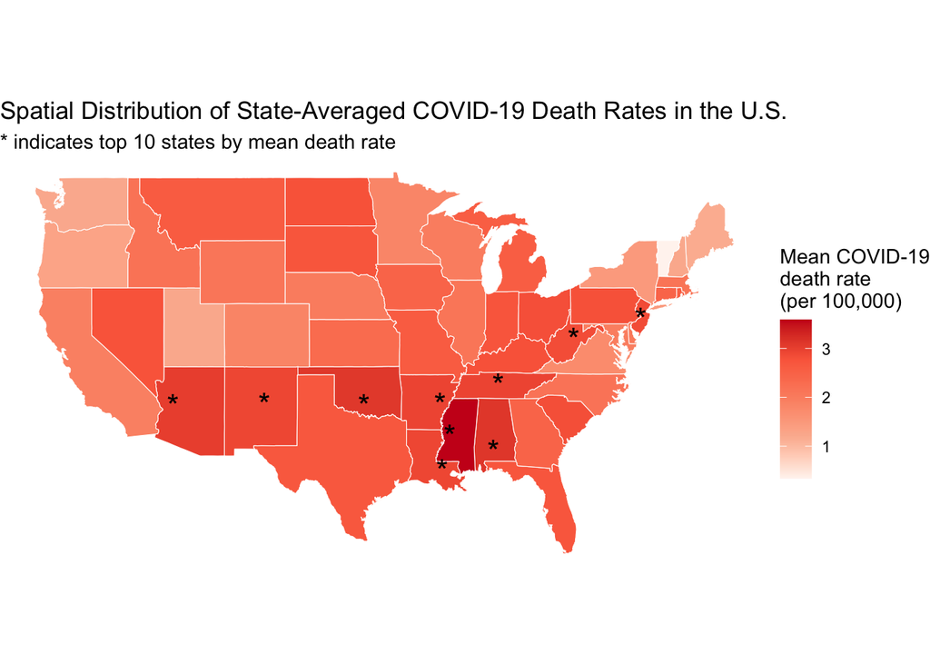

```r
library(maps)
us_map <- map_data("state")

state_avg <- state_avg %>%
  mutate(
    state_full = state.name[match(state, state.abb)],
    state_lower = tolower(state_full)
  )

map_df <- us_map %>%
  left_join(state_avg, by = c("region" = "state_lower"))

top10_states <- state_avg %>%
  arrange(desc(mean_death_rate)) %>%
  slice(1:10) %>%
  dplyr::select(state_lower, mean_death_rate)


label_df <- map_df %>%
  filter(region %in% top10_states$state_lower) %>%
  group_by(region) %>%
  summarise(
    long = mean(long),
    lat = mean(lat)
  )

ggplot(map_df, aes(x = long, y = lat, group = group, fill = mean_death_rate)) +
  geom_polygon(color = "white", size = 0.2) +
  scale_fill_gradientn(
    colors = c("#fff5f0", "#fcbba1", "#fc9272", "#fb6a4a", "#cb181d"),
    name = "Mean COVID-19\ndeath rate\n(per 100,000)"
  ) +
  geom_text(
    data = label_df,
    aes(x = long, y = lat),
    label = "*",
    color = "black",
    size = 6,
    inherit.aes = FALSE
  ) +
  coord_fixed(1.3) +
  labs(
    title = "Spatial Distribution of State-Averaged COVID-19 Death Rates in the U.S.",
    subtitle = "* indicates top 10 states by mean death rate"
  ) +
  theme_void()
```

Looking at the map, it appears that the highest COVID-19 death rates are concentrated in the south, with many of the top 10 highest death rate states in this region. Mississippi appears to have the highest death rate of any state. New England/the Northeast U.S. seems to have generally the lowest COVID-19 death rates.

## 8. ggplot extension

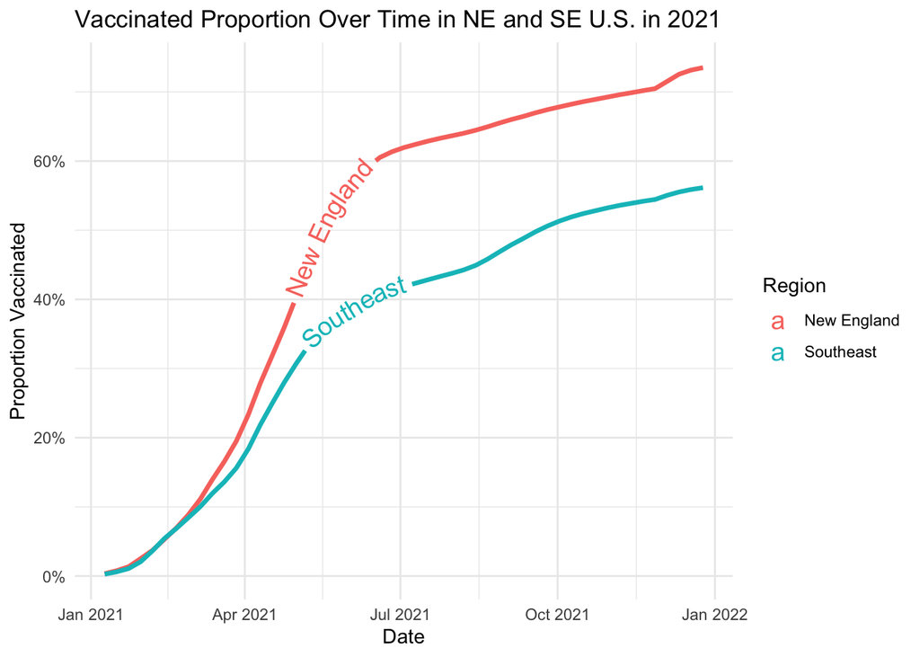

```r
library(gganimate)
library(gifski)
library(scales)
library(geomtextpath)

vacc_region_sub <- covid %>%
  filter(region_name %in% c("Southeast", "New England"), mmwr_year %in% c(2021)) %>%
  group_by(region_name, date) %>%
  summarise(
    vaccinated = sum(series, na.rm = TRUE),
    population = sum(pop, na.rm = TRUE),
    .groups = "drop"
  ) %>%
  mutate(vacc_prop = vaccinated / population)

ggplot(vacc_region_sub, aes(x = date, y = vacc_prop, color = region_name)) +
  geom_textline(aes(label = region_name), size = 5, linewidth = 1.2) +
  scale_y_continuous(labels = percent_format(accuracy = 1)) +
  scale_x_date(date_labels = "%b %Y") +
  labs(
    title = "Vaccinated Proportion Over Time in NE and SE U.S. in 2021",
    x = "Date",
    y = "Proportion Vaccinated",
    color = "Region"
  ) +
  theme_minimal()
```